# Catálogo y auditoría de las bases agregadas de Aprender (2016-2025)

Qué se puede y qué no se puede comparar entre ediciones

Fecha de publicación

21 de noviembre de 2026

**NotaSobre este informe**

Elaboración propia a partir de datos abiertos de la Secretaría de Educación de la Nación. **No es una publicación oficial** de la Secretaría ni refleja su posición. Los colores están inspirados en tableros públicos de datos educativos; no se usan logos, escudos ni tipografías institucionales.

# 1 Resumen

Se auditaron las 12 bases agregadas de Matemática de Aprender publicadas como datos abiertos (ediciones 2016 a 2025), con el objetivo de saber qué elementos se pueden armonizar entre ediciones y cuáles no. **No se comparó el desempeño entre ediciones.**

- **Estructura:** 10 de las 12 bases traen departamento; las dos muestrales (2016 secundaria y 2022 primaria) solo llegan a jurisdicción.
- **Jurisdicciones:** hasta 2019 la columna `cod_provincia` guarda **nombres, no códigos**, con 4 ortografías distintas del canónico (por ejemplo “Buenos aires” o “Ciudad de Buenos Aires”). Aparecen en 6 bases y se armonizan con una regla simple. La base de 2019S tiene 23 jurisdicciones: **falta Chubut**.
- **Categorías:** hay 4 casos de “Sin datos” en sector o ámbito (una fila por caso, en 2016) y una etiqueta distinta (“Privada” en lugar de “Privado”) en la muestra de 2016.
- **Desempeño:** las cuatro columnas de niveles existen en todas las bases, pero el nombre del primer nivel tiene 4 variantes.
- **Nivel socioeconómico:** 5 bases (2016 a 2018) no tienen columnas de NSE, y las demás usan 3 definiciones distintas (niveles, quintiles, o ambos en una misma base).
- **Variables:** se identifican 28 familias por prefijo de nombre, y solo 2 están presentes en las 12 bases.
- **Diccionario:** hay hoja para 11 de las 12 bases. No hay para 2025.

# 2 Pregunta y alcance

Entre las bases agregadas de Aprender publicadas como datos abiertos, ¿qué elementos (claves geográficas, categorías, columnas de desempeño, nivel socioeconómico y familias de variables) se pueden armonizar entre ediciones, y cuáles no?

Fuera de alcance: cualquier serie o comparación de desempeño entre ediciones, el emparejamiento de ítems de cuestionarios, Lengua, el Relevamiento Anual y cualquier juicio sobre la calidad de los datos de una jurisdicción.

# 3 Inventario

| Base | Año | Nivel | Tipo | Filas | Columnas | Clave de provincia | Tiene departamento |
| --- | --- | --- | --- | --- | --- | --- | --- |
| 2016P | 2016 | Primaria | no indicado | 1.173 | 308 | cod_provincia | sí |
| 2016S | 2016 | Secundaria | no indicado | 1.142 | 545 | cod_provincia | sí |
| 2016Sm | 2016 | Secundaria | muestral | 86 | 522 | cod_provincia | no |
| 2017S | 2017 | Secundaria | no indicado | 1.178 | 1.092 | cod_provincia | sí |
| 2018? | 2018 | no indicado | no indicado | 1.197 | 669 | cod_provincia | sí |
| 2019S | 2019 | Secundaria | censal | 1.178 | 1.414 | cod_provincia | sí |
| 2021P | 2021 | Primaria | censal | 1.186 | 836 | jurisdiccion | sí |
| 2022Pm | 2022 | Primaria | muestral | 84 | 603 | jurisdiccion | no |
| 2022S | 2022 | Secundaria | censal | 1.213 | 1.229 | jurisdiccion | sí |
| 2023P | 2023 | Primaria | censal | 1.195 | 1.022 | jurisdiccion | sí |
| 2024S | 2024 | Secundaria | censal | 1.175 | 1.035 | jurisdiccion | sí |
| 2025P | 2025 | Primaria | censal | 1.191 | 361 | jurisdiccion | sí |

“No indicado” significa que el dato no figura en el nombre del archivo; no se supone. El nivel de la base de 2018 queda sin determinar. La letra final de cada código indica el nivel (P primaria, S secundaria) y “m” indica base muestral.

# 4 Claves y categorías

## 4.1 Jurisdicciones

Los valores de provincia se normalizan recortando espacios, pasando a minúsculas y quitando tildes, más dos reglas manuales (ver el diseño). Con eso, cada base se mapea sin ningún valor sin resolver a las 24 jurisdicciones canónicas (los nombres de la base de 2025). Estas son las variantes encontradas:

| Base | Valor en la base | Equivale a | Filas |
| --- | --- | --- | --- |
| 2016P | Tierra del Fuego | Tierra del Fuego, Antártida e Islas del Atlántico Sur | 5 |
| 2016S | Buenos aires | Buenos Aires | 315 |
| 2016S | Tierra del Fuego | Tierra del Fuego, Antártida e Islas del Atlántico Sur | 4 |
| 2016Sm | Buenos aires | Buenos Aires | 4 |
| 2016Sm | Tierra del Fuego | Tierra del Fuego, Antártida e Islas del Atlántico Sur | 2 |
| 2017S | (espacio inicial) Buenos Aires | Buenos Aires | 321 |
| 2017S | Ciudad de Buenos Aires | Ciudad Autónoma de Buenos Aires | 30 |
| 2017S | Tierra del Fuego | Tierra del Fuego, Antártida e Islas del Atlántico Sur | 4 |
| 2018? | Buenos aires | Buenos Aires | 325 |
| 2018? | Tierra del Fuego | Tierra del Fuego, Antártida e Islas del Atlántico Sur | 5 |
| 2019S | Buenos aires | Buenos Aires | 326 |
| 2019S | Tierra del Fuego | Tierra del Fuego, Antártida e Islas del Atlántico Sur | 4 |

En la base de 2019S hay 23 jurisdicciones y falta **Chubut**. Los archivos publicados no explican por qué.

## 4.2 Sector y ámbito

| Base | Variable | Filas con “Sin datos” |
| --- | --- | --- |
| 2016P | sector | 1 |
| 2016P | ambito | 1 |
| 2016S | sector | 1 |
| 2016S | ambito | 1 |

La muestra de 2016 de secundaria usa la etiqueta “Privada”; el resto usa “Privado”. Cualquier unión entre bases requiere unificar estas etiquetas.

# 5 Columnas de desempeño

Cada base tiene cuatro columnas `mdesemp_*` (los cuatro niveles de desempeño). El nombre del primer nivel cambia entre ediciones, pero se identifica con un patrón. Los totales ponderados se calculan solo como control interno de lectura; **no son comparables entre ediciones** y no se grafica ninguna evolución.

| Base | Nombre del primer nivel | Total ponderado | Filas con total cero | Celdas vacías |
| --- | --- | --- | --- | --- |
| 2016P | Por_debajo_del_Nivel_Básico | 750.807 | 1 | 60 |
| 2016S | Por_debajo_de_básico | 442.458 | 3 | 598 |
| 2016Sm | Por_debajo_del_Nivel_Básico | 719.589 | 1 | 11 |
| 2017S | Por_debajo_del_nivel_básico | 464.260 | 1 | 587 |
| 2018? | Por_debajo_del_nivel_básico | 729.625 | 0 | 57 |
| 2019S | Por_debajo_del_nivel_básico | 468.154 | 3 | 702 |
| 2021P | Por_debajo_del_nivel_básico | 760.908 | 0 | 53 |
| 2022Pm | Por_debajo_del_básico | 756.699 | 0 | 5 |
| 2022S | Por_debajo_del_básico | 574.444 | 1 | 1344 |
| 2023P | Por_debajo_del_nivel_básico | 748.350 | 4 | 72 |
| 2024S | Por_debajo_del_nivel_básico | 540.038 | 1 | 1077 |
| 2025P | Por_debajo_del_nivel_básico | 752.018 | 2 | 58 |

Todas las columnas de datos de las 12 bases se leen como numéricas, sin ninguna celda no numérica. Los casilleros vacíos se tratan como cero en el total, igual que en los proyectos anteriores de esta serie.

# 6 Nivel socioeconómico

| Base | Columnas de NSE | Definición |
| --- | --- | --- |
| 2016P | 0 | ninguno |
| 2016S | 0 | ninguno |
| 2016Sm | 0 | ninguno |
| 2017S | 0 | ninguno |
| 2018? | 0 | ninguno |
| 2019S | 5 | quintiles |
| 2021P | 3 | niveles |
| 2022Pm | 3 | niveles |
| 2022S | 8 | niveles y quintiles |
| 2023P | 3 | niveles |
| 2024S | 5 | quintiles |
| 2025P | 5 | quintiles |

Los nombres de columna también cambian dentro de una misma definición (por ejemplo, los quintiles figuran como `NSE_quintiles_Q1`, `NSE_nivel_Q1` o `NSE_nivel_Q1_NSE_más_bajo`, según la edición). Sin las notas técnicas, no es posible afirmar que las categorías de NSE de distintas ediciones midan lo mismo.

# 7 Familias de variables

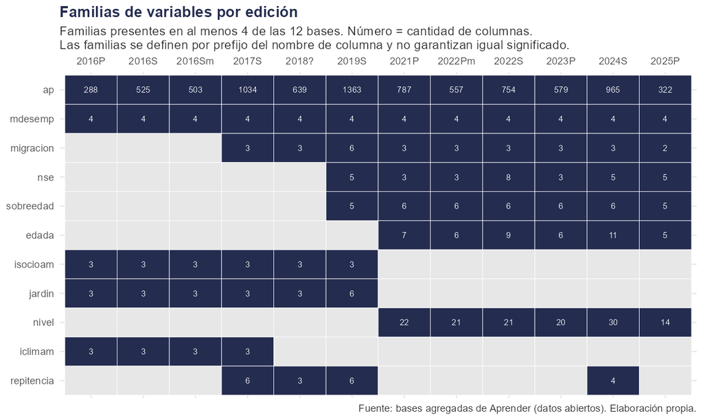

Las familias se definen por el prefijo del nombre de columna, sin garantía de significado. De las 28 familias, solo `ap` (los ítems de cuestionario, con nombres que cambian de formato) y `mdesemp` están en todas las bases. El resto aparece y desaparece entre 2016-2019 y 2021-2025.

# 8 Diccionario

| Base | Hoja del diccionario | Variables |
| --- | --- | --- |
| 2016P | 2016 Estudiantes - APRENDER Pri | 352 |
| 2016S | 2016 Estudiantes - APRENDER Sec | 609 |
| 2016Sm | 2016 Muestra APRENDER - Sec | 566 |
| 2017S | 2017 Estudiantes - APRENDER Sec | 1134 |
| 2018? | 2018 Estudiantes - APRENDER | 705 |
| 2019S | 2019 Estudiantes - APRENDER | 1450 |
| 2021P | 2021 Estudiantes - APRENDER | 866 |
| 2022S | 2022 Estudiantes - APRENDER | 1259 |
| 2022Pm | 2022 Muestra APRENDER - Pri | 633 |
| 2023P | 2023 Estudiantes - APRENDER | 1052 |
| 2024S | 2024 Estudiantes - APRENDER Sec | 1065 |
| 2025P | sin hoja |  |

Hojas del diccionario sin base agregada en la carpeta de datos: 2016 Muestra APRENDER - Pri; 2017 Estudiantes - APRENDER Pri; 2019 Muestra APRENDER - Sec; 2024 Estudiantes - APRENDER Pri.

El diccionario describe las variables de las bases de **estudiantes**; no necesariamente documenta las columnas de las bases agregadas (que derivan de ellas). La equivalencia entre bases y hojas se hizo por año y nivel, y es un supuesto.

# 9 Guía de compatibilidad

| Elemento | ¿Armonizable? | Evidencia y condición |
| --- | --- | --- |
| Nombre de jurisdicción | Sí | Normalización de texto y dos reglas manuales; falta una jurisdicción en una base |
| Departamento | Parcial | No existe en las dos bases muestrales |
| Sector y ámbito | Sí, con cuidado | Unificar “Privada” y “Privado” y decidir qué hacer con “Sin datos” |
| Columnas de desempeño (nombres) | Sí | Cuatro columnas en todas las bases; se identifican por patrón |
| Valores de desempeño | No evaluado | Requiere leer las notas técnicas de cada edición |
| NSE | No | Ausente en 2016-2018; tres definiciones distintas en las demás |
| Resto de variables | No evaluado | Los ítems de cuestionario no se emparejaron entre ediciones |

# 10 Limitaciones

1. Las familias por prefijo no garantizan que dos columnas con el mismo prefijo midan lo mismo en distintas ediciones.
2. No se emparejó ningún ítem de cuestionario entre ediciones.
3. El diccionario documenta las bases de estudiantes; la equivalencia con las bases agregadas es un supuesto.
4. El nivel de la base de 2018 y el tipo de varias ediciones no figuran en los nombres de archivo.
5. No se evaluó la comparabilidad del desempeño.
6. Los hallazgos describen los archivos publicados y no explican por qué son así.

# 11 Reproducibilidad

Los datos no están en el repositorio. Las instrucciones de descarga están en `data/README.md`. Para regenerar este informe:

```
Rscript R/01_inventario.R
Rscript R/02_claves.R
Rscript R/03_desempeno.R
Rscript R/04_nse.R
Rscript R/05_familias.R
Rscript R/06_diccionario.R
quarto render reports/informe.qmd
```

```
Versión de R: R version 4.6.0 (2026-04-24 ucrt)
```

```
dplyr 1.2.1 | readr 2.2.0 | readxl 1.4.5 | knitr 1.51
```